# Multilevel tutorial 2, part II

### Setup

```r
# Load packages
if(!require(lme4)){install.packages('lme4')}
```

```r
if(!require(ggplot2)){install.packages('ggplot2')}
require(ggplot2)
require(lme4)

# Source the inv.logit and logit functions for ease of use.
source('http://pastebin.com/raw.php?i=v1PDDYz7')
setwd('D:/files/teaching/2014multilevel/')
```

## Question 1

```r
polls <- read.table('2_polls.subset.dat')
str(polls)
```

```
## 'data.frame':    2193 obs. of  10 variables:
##  $ org   : Factor w/ 1 level "cbsnyt": 1 1 1 1 1 1 1 1 1 1 ...
##  $ year  : int  7 7 7 7 7 7 7 7 7 7 ...
##  $ survey: int  9158 9158 9158 9158 9158 9158 9158 9158 9158 9158 ...
##  $ bush  : int  NA 1 0 0 1 1 1 1 0 0 ...
##  $ state : int  7 39 31 7 33 33 39 20 33 40 ...
##  $ edu   : int  3 4 2 3 2 4 2 2 4 1 ...
##  $ age   : int  1 2 4 1 2 4 2 4 3 3 ...
##  $ female: int  1 1 1 1 1 1 0 1 0 0 ...
##  $ black : int  0 0 0 0 0 0 0 0 0 0 ...
##  $ weight: int  923 558 448 923 403 317 1532 896 884 4091 ...
```

The page does not work anymore so we will have to make due with the description inside the dataset.

## Question 2

The dataset contains data from 49 unique states.

## Question 3

```r
M1 <- glm(bush ~ 1, data=polls, family=binomial(link="logit"))
```

The intercept for the intercept model is 0.2323046, which is equal to a probability of 0.5578164.

## Question 4

```r
M2 <- glmer(bush ~ 1 + (1 | state), data=polls, family=binomial(link="logit"))
print(M2)
```

```
## Generalized linear mixed model fit by maximum likelihood (Laplace
##   Approximation) [glmerMod]
##  Family: binomial  ( logit )
## Formula: bush ~ 1 + (1 | state)
##    Data: polls
##       AIC       BIC    logLik  deviance  df.resid
##  2749.188  2760.405 -1372.594  2745.188      2013
## Random effects:
##  Groups Name        Std.Dev.
##  state  (Intercept) 0.3688
## Number of obs: 2015, groups:  state, 49
## Fixed Effects:
## (Intercept)
##      0.2623
```

The estimated variance in the intercept is estimated at 0.1360134, which results in a variance of 0.533951 in the probabilities, which is large. This indicates that the base rate for voting pro-Bush varies highly across states.

## Question 5

```r
M3 <- glmer(bush ~ 1 + age + (1 | state), data=polls, family=binomial(link="logit"))
summary(M3)
```

```
## Generalized linear mixed model fit by maximum likelihood (Laplace
##   Approximation) [glmerMod]
##  Family: binomial  ( logit )
## Formula: bush ~ 1 + age + (1 | state)
##    Data: polls
##
##      AIC      BIC   logLik deviance df.resid
##   2750.8   2767.6  -1372.4   2744.8     2012
##
## Scaled residuals:
##     Min      1Q  Median      3Q     Max
## -1.5234 -1.0802  0.7350  0.8743  1.2365
##
## Random effects:
##  Groups Name        Variance Std.Dev.
##  state  (Intercept) 0.1372   0.3704
## Number of obs: 2015, groups:  state, 49
##
## Fixed effects:
##             Estimate Std. Error z value Pr(>|z|)
## (Intercept)  0.32910    0.13199   2.493   0.0127 *
## age         -0.02928    0.04666  -0.628   0.5303
## ---
## Signif. codes:  0 '***' 0.001 '**' 0.01 '*' 0.05 '.' 0.1 ' ' 1
##
## Correlation of Fixed Effects:
##     (Intr)
## age -0.807
```

The results indicate that age is not a significant predictor, which is corroborated by a model comparison, p = 0.53.

## Question 6

```r
M4 <- glmer(bush ~ 1 + age + (1 + age | state), data=polls, family=binomial(link="logit"))
summary(M4)
```

```
## Generalized linear mixed model fit by maximum likelihood (Laplace
##   Approximation) [glmerMod]
##  Family: binomial  ( logit )
## Formula: bush ~ 1 + age + (1 + age | state)
##    Data: polls
##
##      AIC      BIC   logLik deviance df.resid
##   2754.8   2782.8  -1372.4   2744.8     2010
##
## Scaled residuals:
##     Min      1Q  Median      3Q     Max
## -1.5296 -1.0811  0.7331  0.8754  1.2295
##
## Random effects:
##  Groups Name        Variance  Std.Dev. Corr
##  state  (Intercept) 1.445e-01 0.380068
##         age         1.698e-05 0.004121 -1.00
## Number of obs: 2015, groups:  state, 49
##
## Fixed effects:
##             Estimate Std. Error z value Pr(>|z|)
## (Intercept)  0.32975    0.13317   2.476   0.0133 *
## age         -0.02951    0.04677  -0.631   0.5280
## ---
## Signif. codes:  0 '***' 0.001 '**' 0.01 '*' 0.05 '.' 0.1 ' ' 1
##
## Correlation of Fixed Effects:
##     (Intr)
## age -0.810
```

The variance for the random effect of age is only 1.698264110^{-5}, which is small. Model comparison indicates that this new model, with random effect of age, does not fit better than the previous model, p = 0.998.

## Question 7

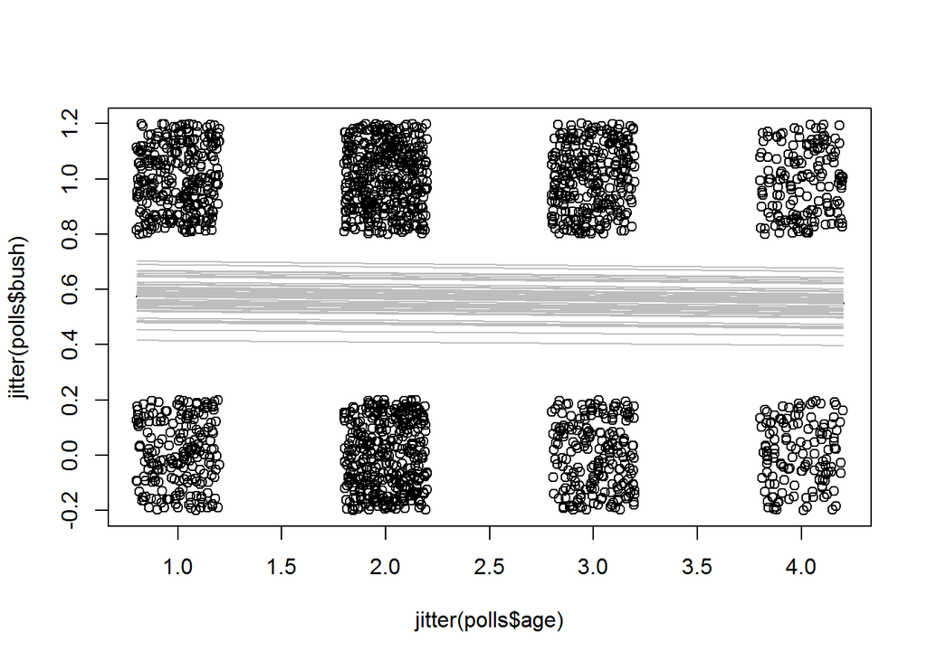

## Question 8

I would personally prefer the random intercept model, because there is clear variance in the intercept, but not in the effects of age. If seriously considering the topic, I would revisit what other variables might matter, such as education.

## Question 9

See above.

## Question 10

```r
#mer(y ~ 1 + (1 | group) + x, data=, family=binomial(link="logit"))
#coef()
#fixef()
#ranef()
```